# Equilibrium C stocks and fluxes at ATTO represented with the Porce model

Carlos A. Sierra

2023-10-17

## Introduction

This document presents a workflow for using the R package `porce` for the computation of equilibrium carbon stocks and respiration for the ATTO site in central Amazonia. The `porce` package is a collection of functions that allows the implementation of *Photosynthesis, allocation, Organic matter dynamics, and RadioCarbon Exchange* (PORCE) models. Rather than one single model, PORCE models are flexible implementation of different functions that can build a compartmental dynamical system, for which stocks and release fluxes can be computed.

In this document I show how to implement a simple ecosystem model for predicting equilibrium carbon stocks for central Amazon forests, using the Amazon Tall Tower Observatory (ATTO) site as a reference.

The `porce` package and PORCE models build on previous work done at the Porce region of Colombia (Carlos A. Sierra, Estupinan-Suarez, and Chanca 2021), where I developed in the past a compartmental model for predicting stocks and fluxes of carbon for seven ecosystem compartments. Parameter values from this previous model can be used as prior information for applications in other sites.

Here, I use data of gross primary production (GPP) from ATTO (Botı́a et al. 2022) together with prior parameter values obtained from the Porce region, to develop a PORCE model for ATTO. In the following sections, I show how to setup the simulations and plot the results.

## Initial setup

There are three main packages that we will use for this simulation. First, the package `porce` which is the main focus of this document and is used to predict C stocks and respiration. Second, the package `parallel`, which is used to parallelize the code and use multiple CPU cores. The advantage in speed by using this package is enormous. Third, SoilR is used here to run simulations of radiocarbon dynamics over time.

```r
library(porce)
library(parallel)
library(SoilR)
```

We need to specify the number of CPU cores available for the computations. This number is different for every machine you would use, so I prefer to use all cores available minus two. Using all cores would probably slow down other running tasks in your computer, so it’s good to leave two cores for other tasks, but you are flexible to specify this as you want. The following code, initializes a cluster in your computer with the desired number of cores.

```r
no_cores <- detectCores() - 2
cl <- makeCluster(no_cores)
```

Finally, we read the available information for the simulations. GPP data from Botı́a et al. (2022) is available in the same folder where this Rmd file is stored. Prior values of parameter values from Carlos A. Sierra, Estupinan-Suarez, and Chanca (2021) is already available inside the `porce` package in the object `modpars`. We only need to create a vector of names for the pools that we will represent with this model.

```r
monthly_gpp<-read.csv("inputs/ATTO_INST_monthlyGPP_2014_2019.csv")
pool_names<-c("Foliage", "Wood", "Fine roots", "Coarse roots", "Fine litter", "CWD", "Soil (0-30 cm)")
```

## Design of the simulations

Our objective here is to represent C stocks and respiration for all ecosystem compartments at equilibrium. We have a time series of monthly values of GPP from 2014 to 2019, and 1000 possible sets of parameter values stored in the `modpars` dataset. Therefore, we will produce estimates of stocks and fluxes based on the uncertainty of the carbon inputs (i.e. GPP uncertainty) and uncertainty in the values of the compartmental matrix that can be build from the available parameter values. For this purpose, we will run a set of 1000 simulations predicting carbon stocks and fluxes using 1000 combinations of values of GPP and all parameter sets in `modpars`.

Because we will make predictions based on the assumption of equilibrium where inputs and rates do not change over time, we will implement a model of class `lam`, linear autonomous model (Carlos A. Sierra et al. 2018). This type of models only require knowledge on the vector of carbon inputs to the system, and a compartmental matrix with fixed coefficients. In the following sections, I will show how to build these components of a `lam` using functions available in `porce`.

## Building vectors of carbon inputs

First, let’s plot the available GPP data for ATTO. Botı́a et al. (2022) provide three time series of GPP (units of gC m<sup>-2</sup> month<sup>-1</sup> ) for different wind friction velocity corrections (u*). We can plot the data and see that the series suggest the system in a quasy-equilibrium, without long-term trends but with some seasonal dynamics.

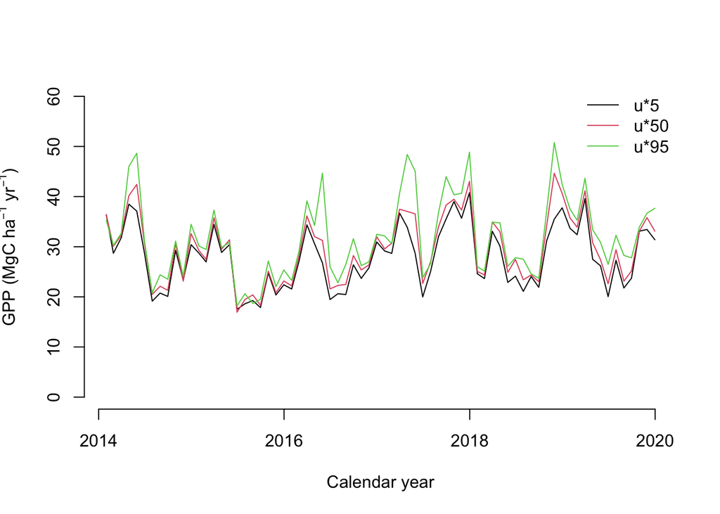

```r
matplot(as.Date(monthly_gpp[,1]), monthly_gpp[,-1]* 1e-06 * 1e04 *12, type="l",
        lty=1, col=1:3, ylab=expression(paste("GPP (MgC h", a^-1, " y", r^-1,")")), xlab="Calendar year",
        ylim=c(0,60), bty="n")
legend("topright", c("u*5", "u*50", "u*95"), lty=1, col=1:3, bty="n")
```

Because we are interested in simulating the uncertainty in GPP assuming the system in equilibrium, we ignore the seasonal trend and compute an average value of GPP with a corresponding uncertainty that includes temporal variability and uncertainty due to the u* correction.

```r
GPPmean<- mean(unlist(monthly_gpp[-1])) * 1e-06 * 1e04 *12
GPPsd<- sd(unlist(monthly_gpp[-1])) * 1e-06 * 1e04 *12
```

Notice that in the code above, units are converted from gC m<sup>-2</sup> month<sup>-1</sup> to Mg C ha<sup>-1</sup> yr<sup>-1</sup>.

We can now build a vector of 1000 random variates of GPP based on the mean and standard error of the observed values. This standard deviation is obtained as the standard deviation of the observed values divided by square root of the number of years available in the time series, i.e. $\sqrt{6}$ = 2.4494897.

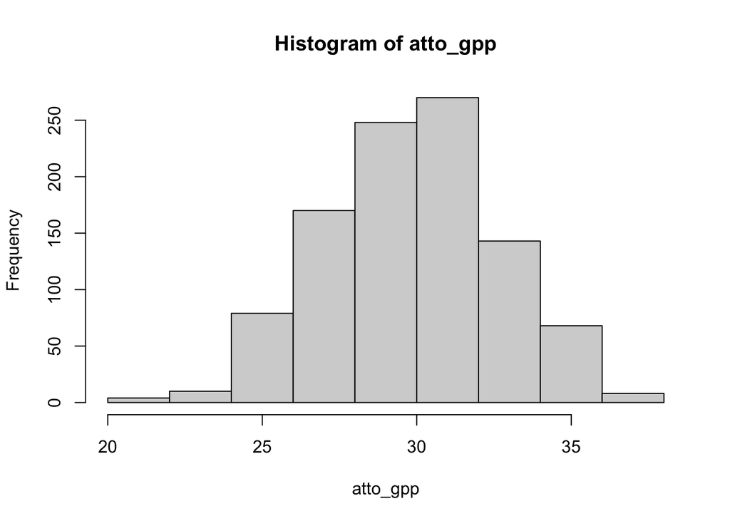

```r
set.seed(1033)
atto_gpp<-rnorm(n=nrow(modpars), mean=GPPmean, sd=GPPsd/sqrt(6))
hist(atto_gpp)
```

To build a vector of inputs in the format required for the subsequent simulations we use the function `inputGPP` from `porce`. As an example, the input vector for the mean value of GPP can be obtained as

```r
inputGPP(GPPmean)
```

```
## [1] 29.80287  0.00000  0.00000  0.00000  0.00000  0.00000  0.00000
```

Notice that the GPP only enters the first ecosystem compartment, foliage, and therefore inputs to all other compartments are equal to 0.

## Building compartmental matrices

`porce` includes the function `makeB` to take sets of parameters in the `modpars` dataset and build a compartmental matrix from it. As an example, we can take the first row of the `modpars` dataset and build a compartmental matrix as

```r
modpars[1,]
```

```
##           k1           k2           k3           k4           k5           k6
## 2.9857557418 0.0347442137 0.0264817956 0.0221973427 2.9582379850 0.2421847927
##           k7      alpha21      alpha31      alpha41      alpha51      alpha53
## 0.0199036158 0.1766980864 0.0101609660 0.0345868465 0.3193791097 0.9990935981
##      alpha62      alpha64      alpha75      alpha76
## 0.2077075199 0.0007374263 0.1851963835 0.9995461099
```

```r
makeB(modpars[1,])
```

```
##             [,1]         [,2]        [,3]          [,4]      [,5]       [,6]
## [1,] -2.98575574  0.000000000  0.00000000  0.0000000000  0.000000  0.0000000
## [2,]  0.52757733 -0.034744214  0.00000000  0.0000000000  0.000000  0.0000000
## [3,]  0.03033816  0.000000000 -0.02648180  0.0000000000  0.000000  0.0000000
## [4,]  0.10326788  0.000000000  0.00000000 -0.0221973427  0.000000  0.0000000
## [5,]  0.95358801  0.000000000  0.02645779  0.0000000000 -2.958238  0.0000000
## [6,]  0.00000000  0.007216634  0.00000000  0.0000163689  0.000000 -0.2421848
## [7,]  0.00000000  0.000000000  0.00000000  0.0000000000  0.547855  0.2420749
##             [,7]
## [1,]  0.00000000
## [2,]  0.00000000
## [3,]  0.00000000
## [4,]  0.00000000
## [5,]  0.00000000
## [6,]  0.00000000
## [7,] -0.01990362
```

Notice that `makeB` is a very special function that only works for parameter values in `modpars` because it uses parameter names in `modpars` to build the matrix. In other cases you may need to build your own compartmental matrices with user defined functions.

## Run the simulations and plot the results

We are now ready to run simulations with the values of GPP and the `modpars` parameter values. In `porce` the idea is to build first a model object, and then compute stocks and respiration from this model object.

A model object of class `lam` (linear autonomous model) is a dynamical system of the form
$$\frac{dx}{dt} = \dot{x} = u + \mathbf{B}$$
where $x$ is a vector of carbon contents in $n$ compartments, $u$ is a vector of carbon inputs to the system, and $\mathbf{B}$ is a compartmental matrix with the rates of cycling in the diagonal, and rates of transfers among compartments in the off-diagonals. The equilibrium solution of this system is given by
$$x_{eq} = - \mathbf{B}^{-1} \cdot u$$
In `porce`, the equilibrium carbon stock of a `lam` model can be obtained with the function `equilibriumStock`, which takes as only argument an object of class `lam`.

For example, we can build a `lam` model and compute equilibrium carbon stocks with the following code

```r
ATTOmodel <- lam(input=inputGPP(GPPmean), matrix=makeB(modpars[1,]))
equilibriumStock(model=ATTOmodel)
```

```
##            [,1]
## [1,]   9.981683
## [2,] 151.567962
## [3,]  11.435249
## [4,]  46.437414
## [5,]   3.319870
## [6,]   4.519568
## [7,] 146.349340
```

The return value of `equilibriumStock` is a vector of size $n$ with the equilibrium values of each compartment.

Respiration rates for a linear autonomous system can be obtained from the equation
$$r = -1^T \cdot \mathbf{B} \cdot x_{eq}$$
which is implemented in the function `equilibriumOutflux`. We assume here that the output flux from all compartments is in the form of respiration. This can be computed as

```r
equilibriumOutflux(model=ATTOmodel)
```

```
##              [,1]
## [1,] 1.368473e+01
## [2,] 4.172299e+00
## [3,] 2.744820e-04
## [4,] 1.030027e+00
## [5,] 8.002158e+00
## [6,] 4.968148e-04
## [7,] 2.912881e+00
```

These computations are relatively simple to do and can be done for one particular simulation in a regular R session without the need of any package. However, to run the 1000 simulations combining random variates of GPP and prior parameter values, we would need some help. Here is where the functionality of `porce` and `parallel` become useful. We can run all 1000 simulations very easy adopting a functional programming approach, in which we run functions inside functions to create models and compute specific output, taking as input the entire set of values of GPP and model parameters.

We create first a function with these characteristics

```r
pars2stocks<-function(gpp, pars){
  mod<-lam(input=inputGPP(gpp), matrix=makeB(pars))
  equilibriumStock(model=mod)
}
```

Function `pars2stocks` takes parameter values of a model, in this case values of GPP and the parameters needed to build a compartmental matrix, and returns equilibrium carbon stocks. Notice that we are calling functions `inputGPP` and `makeB` inside function `lam`, following a functional approach.

We want to run the function `pars2stocks` 1000 times, and therefore we need to use all possible cores available in our computer to run these simulations. Each core needs to recognize all objects and functions that we will send them, and we use the following code for this purpose

```r
allObjects=ls()
clusterExport(cl, varlist=c(allObjects, "lam", "inputGPP", "makeB", "equilibriumStock", "equilibriumOutflux"))
```

We now run the 1000 simulations using function `clusterMap` from `parallel`. It takes the function `pars2stocks`, the entire vector of GPP variates, and the entire `modpars` dataset, which needs to be split by row for each set of parameter values using function `asplit`. The return of `clusterMap` is a list of vectors with the equilibrium carbon stocks, which for convenience we can `unlist` and save them in a matrix.

```r
stockList<-clusterMap(cl, fun=pars2stocks, gpp=atto_gpp, pars=asplit(modpars, MARGIN = 1))
stocksATTO<-matrix(unlist(stockList), nrow=7, ncol=1000)
```

The results can be ploted with a boxplot to better observe the predicted variability in carbon stocks.

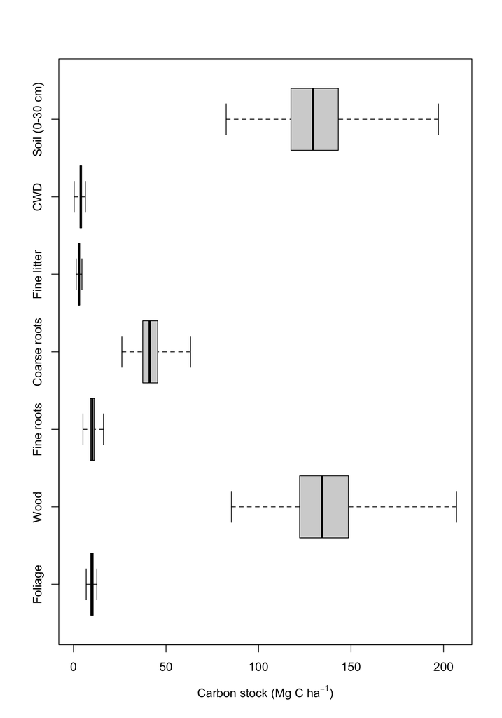

```r
boxplot(stocksATTO, use.cols = FALSE, range=0, horizontal=TRUE, names=pool_names,
        xlab=expression(paste("Carbon stock (Mg C h", a^-1, ")")))
```

A similar procedure is done for the respiration flux

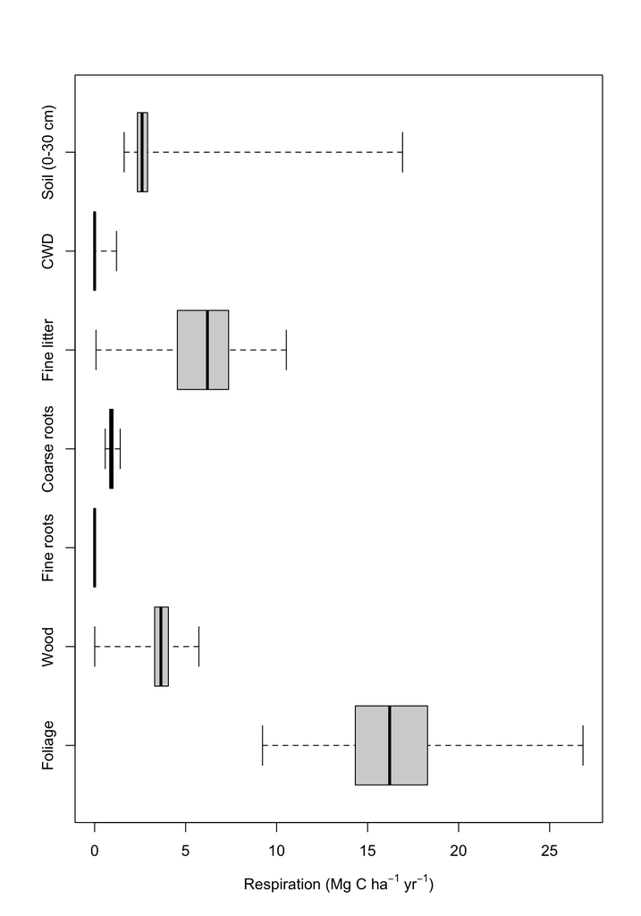

```r
pars2resp<-function(gpp, pars){
  mod<-lam(input=inputGPP(gpp), matrix=makeB(pars))
  equilibriumOutflux(model=mod)
}

respList<-clusterMap(cl, fun=pars2resp, gpp=atto_gpp, pars=asplit(modpars, MARGIN = 1))
respATTO<-matrix(unlist(respList), nrow=7, ncol=1000)

boxplot(respATTO, use.cols = FALSE, range=0, horizontal=TRUE, names=pool_names,
        xlab=expression(paste("Respiration (Mg C h", a^-1, " y", r^-1, ")")))
```

## Aggregated variables and visualizations

In many cases it is useful to combine stocks and fluxes to produce particularly relevant simulation output. For the carbon stocks, the results can be aggregated as aboveground biomass C (foliage and wood), belowground biomass C (fine and coarse roots), and necromass C (fine litter and coarse woody debris).

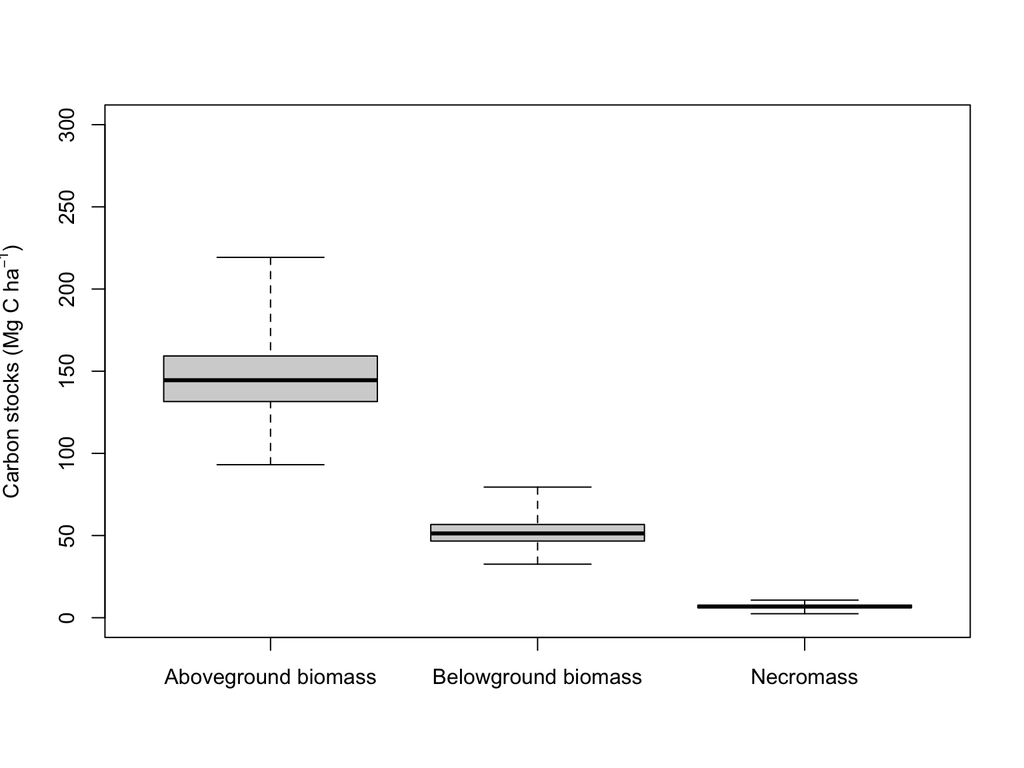

```r
abvg_pools<-match(c("Foliage", "Wood"), table=pool_names)
blwg_pools<-match(c("Fine roots", "Coarse roots"), table=pool_names)
necromass_pools<-match(c("Fine litter", "CWD"), table=pool_names)

abvg<-colSums(stocksATTO[abvg_pools,])
blwg<-colSums(stocksATTO[blwg_pools,])
necro<-colSums(stocksATTO[necromass_pools,])

boxplot(list(abvg, blwg, necro), names=c("Aboveground biomass", "Belowground biomass", "Necromass"), ylim=c(0,300), range=0,
        ylab=expression(paste("Carbon stocks (Mg C h", a^-1, ")")))
```

For respiration, we can aggregate results as autotrophic respiration, heterotrophic respiration and total ecosystem respiration.

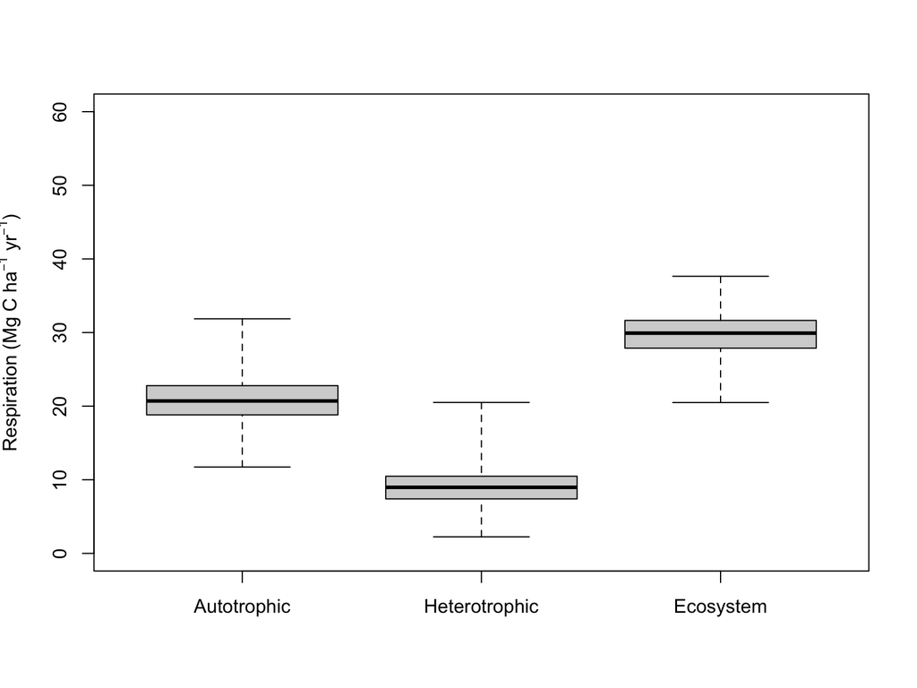

```r
autotroph_pools=match(c("Foliage", "Wood", "Fine roots", "Coarse roots"), table=pool_names)
heterotroph_pools=match(c("Fine litter", "CWD", "Soil (0-30 cm)"), table=pool_names)

Ra<-colSums(respATTO[autotroph_pools,])
Rh<-colSums(respATTO[heterotroph_pools,])
Re<-colSums(respATTO)

boxplot(list(Ra,Rh,Re), names=c("Autotrophic", "Heterotrophic", "Ecosystem"), ylim=c(0,60), range=0,
        ylab=expression(paste("Respiration (Mg C h", a^-1, " y", r^-1, ")")))
```

Net primary production (NPP) can be obtained as the difference between gross primary production and autotrophic respiration. Similarly, the ratio of NPP:GPP, which is often called carbon use efficiency, can be computed from these simulation results.

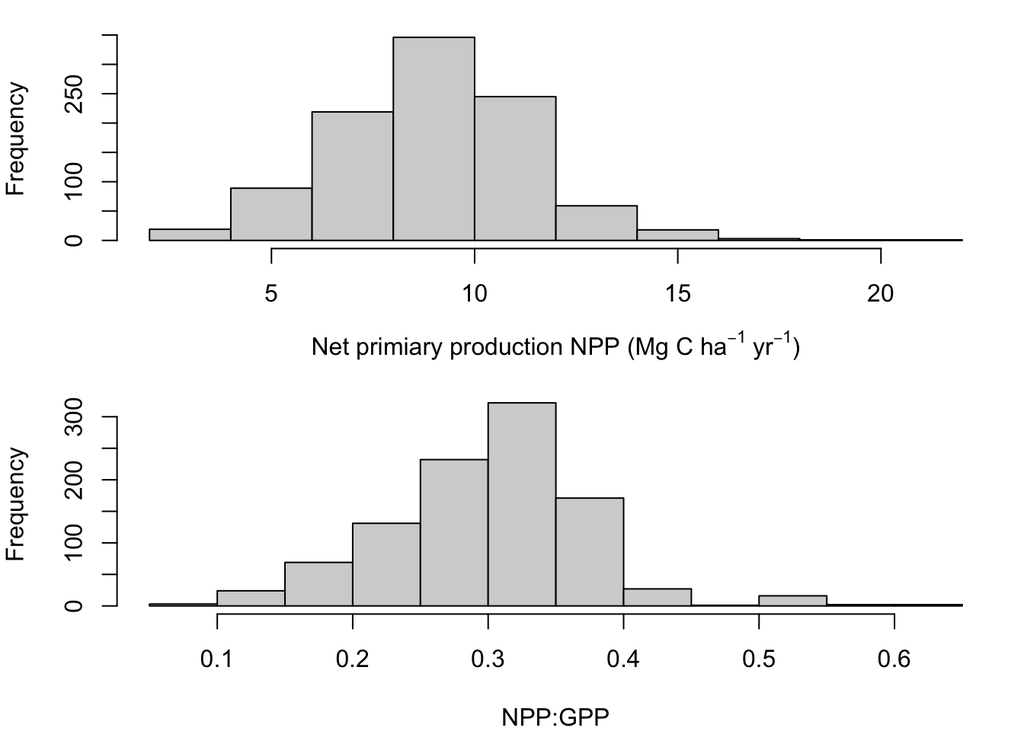

```r
npp<-atto_gpp-Ra
NG<-npp/atto_gpp

par(mfrow=c(2,1), mar=c(4,4,1,1))
hist(npp, main="", xlab=expression(paste("Net primiary production NPP (Mg C h", a^-1, " y", r^-1, ")")))
hist(NG, main="", xlab="NPP:GPP")
```

```r
par(mfrow=c(1,1))
```

The ratio NPP:GPP should be interpreted as the proportion of GPP that is respired by heterotrophic organisms, which on average is 0.3. This implies that from the total amount of GPP, 30 % is on average respired by heterotrophic organisms, and 70% is respired by autotrophic organisms.

Given that the 1000 instances of the model represent uncertainty in model predictions, one could use this information to generate a random arrangement of cells as in spatial landscape of possible model predictions. This could be interpreted as an idealized plot for the study site. As an example, we can aggregate all carbon stocks for this site into a plot of 20 x 50 cells.

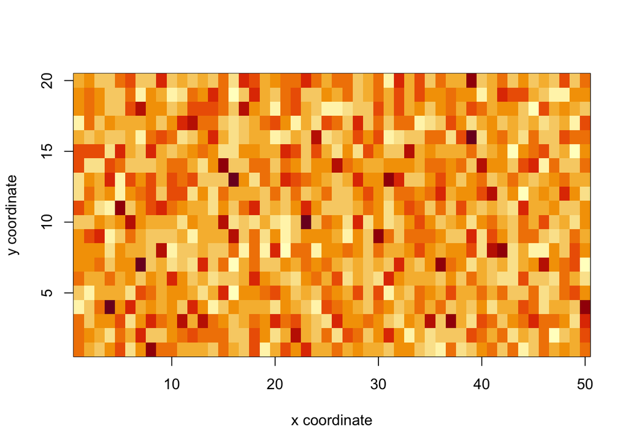

```r
toc<-colSums(stocksATTO)
image(x=1:50,y=1:20,z=matrix(toc,50,20), xlab="x coordinate", ylab="y coordinate")
```

However, care must be taken in not over interpreting this visualization. It is simply a way to organize the different predictions in some spatial way, but it has no ecological meaning. The point is simply that `porce` could be used for spatial predictions if a spatial distribution of input variables is known.

## Radiocarbon dynamics

To simulate radiocarbon dynamics, we need now to use package `SoilR` to produce time-dependent simulations of radiocarbon in ecosystem pools. For this purpose, we need a dataset of atmospheric radiocarbon values covering the entire bomb-radiocarbon period until a recent year. `SoilR` already contains atmospheric radiocarbon data from Hua et al. (2021) that can be extended to more recent years using the procedure described in Carlos A. Sierra (2018). The forecast series is available in the `inputs` folder in this repository, and we can bind both curves as

```r
fNHZ3<-read.csv(file="inputs/NHZ3forecast.csv")
NHZ3<-data.frame(Year=c(Hua2021$NHZone3[-(937:939),1], fNHZ3$time),
                 Delta14C=c(Hua2021$NHZone3[-(937:939),2],Delta14C_from_AbsoluteFractionModern(fNHZ3$F14C)))
```

Then, we build a `Model_14` object following the regular procedure from the `SoilR` package. This needs a vector of time points, initial values for the stocks and their radiocarbon content, and the information related to the compartmental system, i.e. an input vector and a compartmental matrix.

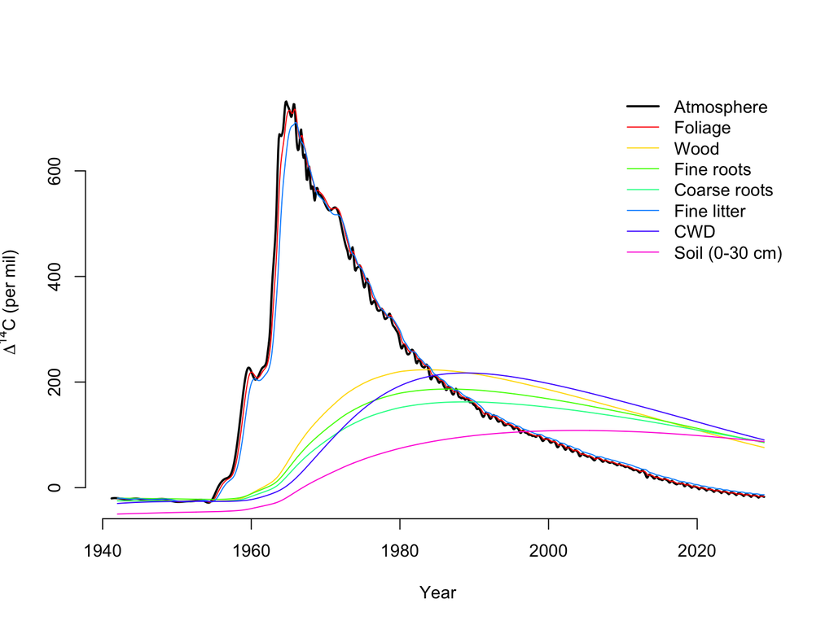

```r
years<-seq(1942,2029, by=1/12)
C14Model<-Model_14(t=years,inputFluxes = inputGPP(GPPmean),A=makeB(modpars[1,]), ivList=stocksATTO[,1],
                   inputFc=BoundFc(NHZ3, lag=0, format="Delta14C"),
                   initialValF=ConstFc(c(-20, -25, -20, -25, -20, -30, -50), format="Delta14C"))
C14t<-getF14(C14Model)

plot(NHZ3, type="l", col=1, lwd=2, ylab=expression(paste(Delta^14, "C (per mil)")), bty="n")
matlines(years, C14t, lty=1, col=rainbow(n=7))
legend("topright", c("Atmosphere",pool_names), col=c(1, rainbow(n=7)), lty=1, lwd=c(2,rep(1,7)), bty="n")
```

A similar computation can be performed for the radiocarbon signature in the respiration of the entire ecosystem, which combines the signature of all the compartments weighed by their contributions to the total respiration flux

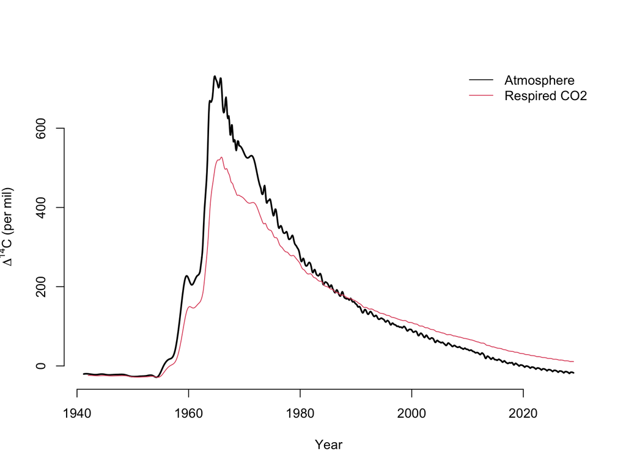

```r
R14t<-getF14R(C14Model)

plot(NHZ3, type="l", col=1, lwd=2, ylab=expression(paste(Delta^14, "C (per mil)")), bty="n")
lines(years,R14t, col=2)
legend("topright", c("Atmosphere", "Respired CO2"), lty=1, col=1:2, bty="n")
```

## Expected radiocarbon values in respiration for a target year

Considering the fact that there is uncertainty in the GPP values and in the parameter values of the model, it is useful to produce uncertainties for the expected radiocarbon values. In particular, if one has data from a specific year, it is possible to predict radiocarbon values for that target year.

For this purpose, we create a new function that takes as arguments model parameter values, builds a `SoilR` model and extracts the radiocarbon value for the target year.

```r
years<-seq(1942,2020, by=1/2) # Make the simulations shorter in time
R14_ty<-function(gpp, pars, targetYear=2019.5){
  Mod<-Model_14(t=years,inputFluxes = inputGPP(gpp),A=makeB(pars), ivList=stocksATTO[,1],
                inputFc=BoundFc(NHZ3, lag=0, format="Delta14C"),
                initialValF=ConstFc(c(-20, -25, -20, -25, -20, -30, -50), format="Delta14C"))
  R14<-getF14R(Mod)
  R14[years==targetYear]
}
```

In this case, we will produce an example for mid 2019, because we actually have some measured data for this particular year.

Initializing a cluster and running the simulations for the entire set of 1000 values of GPP and parameter values, we can recover the radiocarbon values in ecosystem respiration for year 2019.5 (June 2019). Given that the model needs to run computations for a time series since 1940, it takes about one minute to run these computations.

```r
allObjects=ls()
clusterExport(cl, varlist=c(allObjects, "getF14R", "ConstFc", "Model_14", "BoundFc", "inputGPP", "makeB"))
ER14<-clusterMap(cl,fun=R14_ty, gpp=atto_gpp, pars=asplit(x=modpars, MARGIN=1))
ER14_2019<-unlist(ER14)
```

Plotting the results, we can see

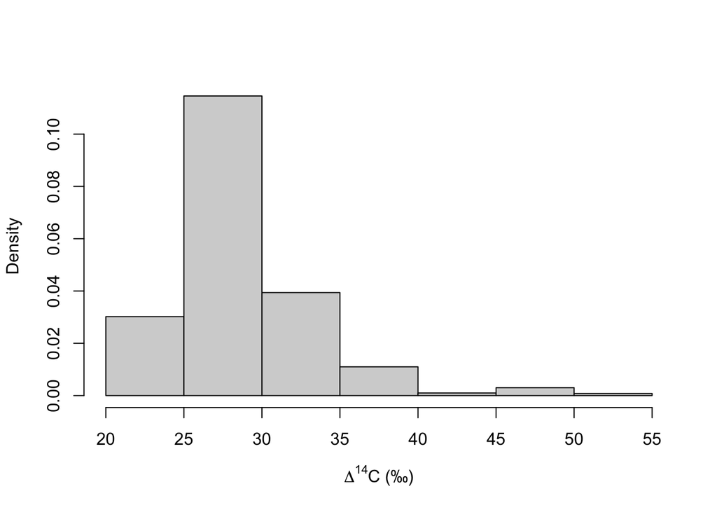

```r
hist(ER14_2019, freq=FALSE, main="", xlab=expression(paste(Delta^14, "C (\u2030)")))
```

These results show that it is likely to obtain radiocarbon values in ecosystem respiration in the range: 20.66, 54.076 per mil, with a mean value of 28.755 per mil and a median of 28.019 per mil.

In addition, we can produce predictions of the radiocarbon content of the different compartments for a target year, which again, can be very useful to compare with observed data.

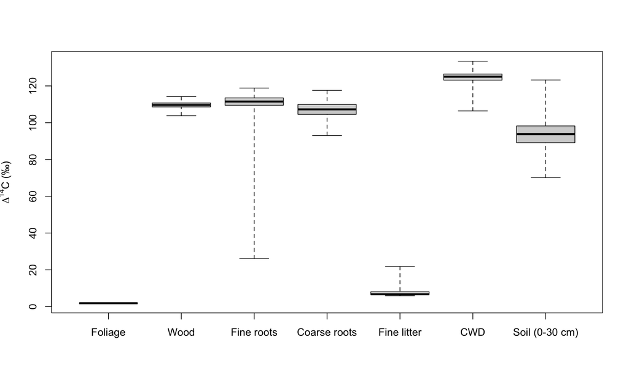

```r
C14_ty<-function(gpp, pars, targetYear=2019.5){
  Mod<-Model_14(t=years,inputFluxes = inputGPP(gpp),A=makeB(pars), ivList=stocksATTO[,1],
                inputFc=BoundFc(NHZ3, lag=0, format="Delta14C"),
                initialValF=ConstFc(c(-20, -25, -20, -25, -20, -30, -50), format="Delta14C"))
  C14<-getF14(Mod)
  C14[years==targetYear]
}

clusterExport(cl, varlist=c(allObjects, "getF14R", "ConstFc", "Model_14", "BoundFc", "inputGPP", "makeB", "getF14"))
RS<-clusterMap(cl,fun=C14_ty, gpp=atto_gpp, pars=asplit(x=modpars, MARGIN=1))
radiocarbonStocks<-matrix(unlist(RS), ncol=7, nrow=1000, byrow = TRUE)
boxplot(radiocarbonStocks, names=pool_names, range=0, ylab=expression(paste(Delta^14, "C (\u2030)")))
```

## References

Botı́a, Santiago, Shujiro Komiya, Julia Marshall, Thomas Koch, Michał Gałkowski, Jost Lavric, Eliane Gomes-Alves, et al. 2022. “The CO2 Record at the Amazon Tall Tower Observatory: A New Opportunity to Study Processes on Seasonal and Inter-Annual Scales.” *Global Change Biology* 28 (2): 588–611. https://doi.org/10.1111/gcb.15905.

Hua, Quan, Jocelyn C Turnbull, Guaciara M Santos, Andrzej Z Rakowski, Santiago Ancapichún, Ricardo De Pol-Holz, Samuel Hammer, et al. 2021. “Atmospheric Radiocarbonfor the Period 1950–2019.” *Radiocarbon*, 1–23. https://doi.org/10.1017/RDC.2021.95.

Sierra, Carlos A. 2018. “Forecasting Atmospheric Radiocarbon Decline to Pre-Bomb Values.” *Radiocarbon* 60 (4): 1055–66. https://doi.org/10.1017/RDC.2018.33.

Sierra, Carlos A., Verónika Ceballos-Núñez, Holger Metzler, and Markus Müller. 2018. “Representing and Understanding the Carbon Cycle Using the Theory of Compartmental Dynamical Systems.” *Journal of Advances in Modeling Earth Systems* 10 (8): 1729–34. https://doi.org/10.1029/2018MS001360.

Sierra, Carlos A., Lina M. Estupinan-Suarez, and Ingrid Chanca. 2021. “The Fate and Transit Time of Carbon in a Tropical Forest.” *Journal of Ecology* 109 (8): 2845–55. https://doi.org/10.1111/1365-2745.13723.